# Alpha Hunter 주간 종합 히든젬 보고서

Week 21 — ONTO·FUTU 손절 도달 · 프로텍 SEPA 7/7 신규 · KRYS 유전자치료 독점 · 중국 3주 연속 없음

Author

Alpha Hunter × Chimera AI

Published

May 23, 2026

# 주간 종합 요약

**Week 21 (2026-05-19 ~ 2026-05-23) 핵심 액션**

- **❌ ONTO (NYSE) 손절 도달**: $238.12 < 손절가 $268 → 워치리스트 제거 (-9.8%)
- **❌ FUTU (NASDAQ) 손절 도달**: $89.76 < 손절가 $120 → 워치리스트 제거 (-41.9%)
- **⚠️ Hugel (145020) SEPA 3/7**: SMA150 < SMA200, Stage 2 이탈 경고
- **🆕 한국 히든젬**: 프로텍 (053610) — LAB 글로벌 최초 양산, SEPA 7/7, 매출+71.7%
- **🆕 미국 히든젬**: Krystal Biotech (KRYS) — FDA 유전자치료 독점, SEPA 7/7, OPM 46%
- **중국**: 3주 연속 SEPA+펀더멘탈 동시 충족 종목 없음

**면책 문구**

이 프로젝트는 가상 투자 시뮬레이션 목적으로 작성되었습니다. 실제 투자 권유가 아닙니다.

# 1 포트폴리오 성과 업데이트

## 1.1 현재 포지션 현황 (2026-05-23)

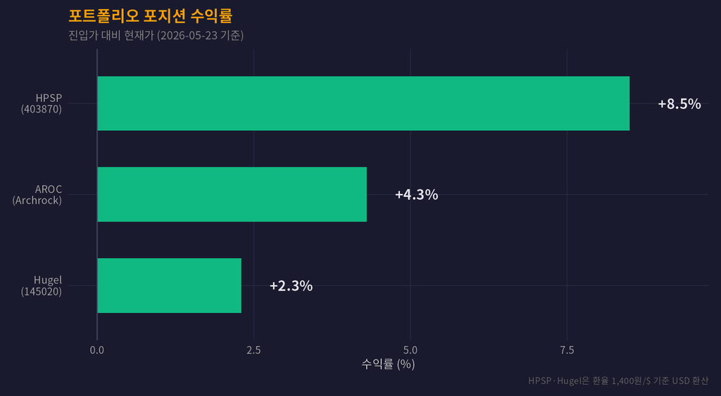

**포지션 요약:**

- **AROC** (Archrock): $35.70 → $37.25 (**+4.3%**) | SEPA 7/7 Stage 2 유지
- **HPSP** (403870): 50,400원 → 54,700원 (**+8.5%**) | SEPA 7/7 Stage 2 복귀!
- **Hugel** (145020): 261,500원 → 267,500원 (**+2.3%**) | ⚠️ SEPA 3/7 — SMA150 < SMA200

## 1.2 포트폴리오 가치 추이

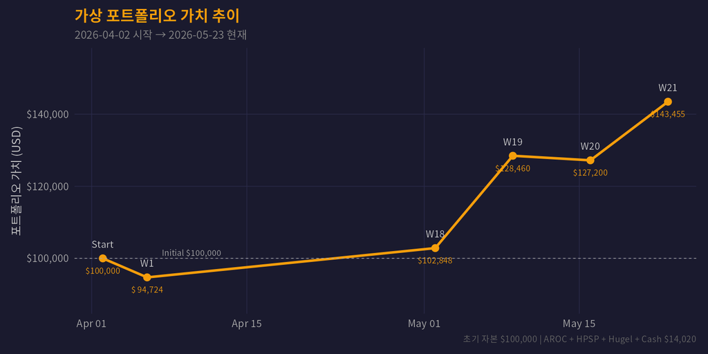

**포트폴리오 성과: $100,000 → $143,455 (+43.5%)**

## 1.3 SEPA 스코어보드

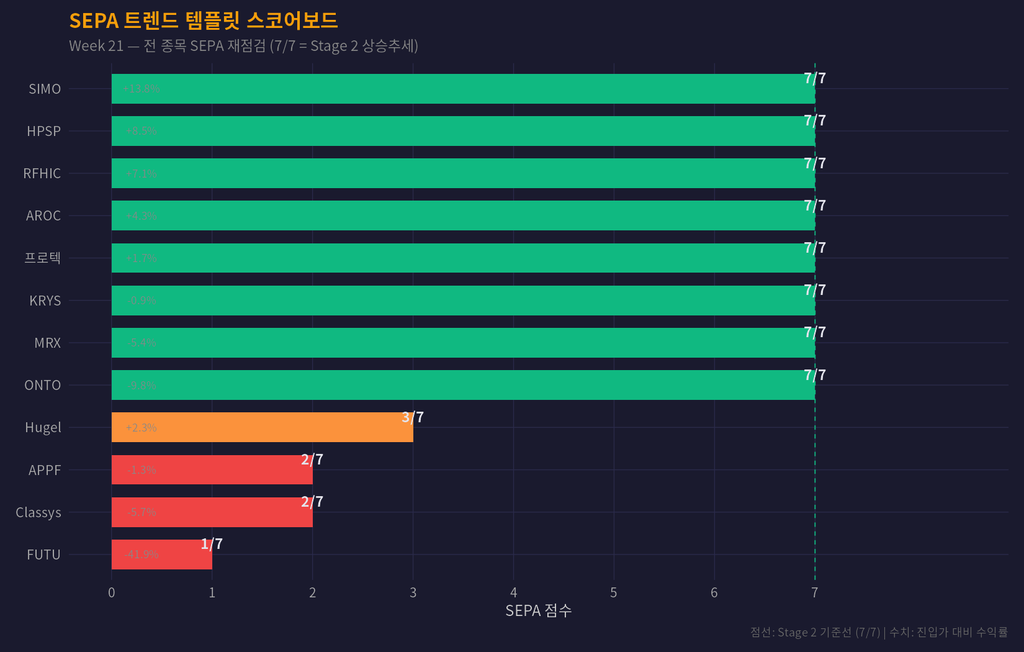

# 2 ❌ 손절 도달 종목

## 2.1 ONTO Innovation (ONTO) — 손절 확정

- **진입가**: $290.76 (2026-05-14)
- **손절가**: $268.00
- **저점**: $238.12 (2026-05-19, 장중)
- **현재가**: $262.25
- **손실**: **-9.8%**
- **원인**: 반도체 업종 전반 매도세, 미중 반도체 수출 규제 강화 우려

> SEPA 7/7을 유지하나 손절가를 장중 하회. 규율에 따라 즉시 매도 처리.

## 2.2 FUTU Holdings (FUTU) — 손절 확정

- **진입가**: $154.51 (2026-05-01 워치리스트)
- **손절가**: $120.00
- **현재가**: $89.76
- **손실**: **-41.9%**
- **원인**: 미중 무역갈등 재격화, ADR 규제 리스크, SEPA 1/7 완전 붕괴

> Stage 4 하락추세 진입. 5/22 급락으로 손절가 대폭 하회. 워치리스트 즉시 제거.

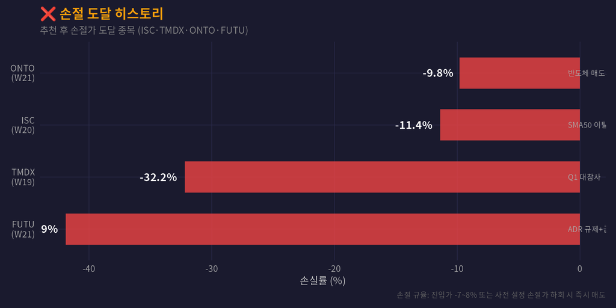

# 3 이번 주 히든젬 요약

## 3.1 🇰🇷 한국: 프로텍 (053610)

**SEPA 7/7 Stage 2 | PEG 0.37x | 매출 +71.7% | 영업이익 +238%**

> 📋 상세 보고서: 프로텍 W21 딥리서치

## 3.2 🇺🇸 미국: Krystal Biotech (KRYS)

**SEPA 7/7 Stage 2 | OPM 46% | 매출 +32% | 현금 $1B 무부채**

- 세계 **유일** FDA 승인 유전자 치료제 VYJUVEK (DEB 독점)
- Gross Margin **95%** — 의약품 중 최고 수준
- KB803 (TGM1 결핍) + KB801 (낭포성섬유증) 파이프라인 2026 데이터
- 목표가: $381.5 (+26%), 손절가: $277
- R:R = **1:3.2**

> 📋 상세 보고서: KRYS W21 딥리서치

## 3.3 🇨🇳 중국: 이번 주 조건 충족 종목 없음 (3주 연속)

- ZTO Express: SEPA 6/7 (50SMA < 150SMA 미통과)
- BIDU: SEPA 5/7 (150SMA 하회)
- FUTU: 1/7 폭락으로 워치리스트 제거
- **미중 무역갈등 + ADR 규제 리스크 지속 → 신규 진입 부적절**

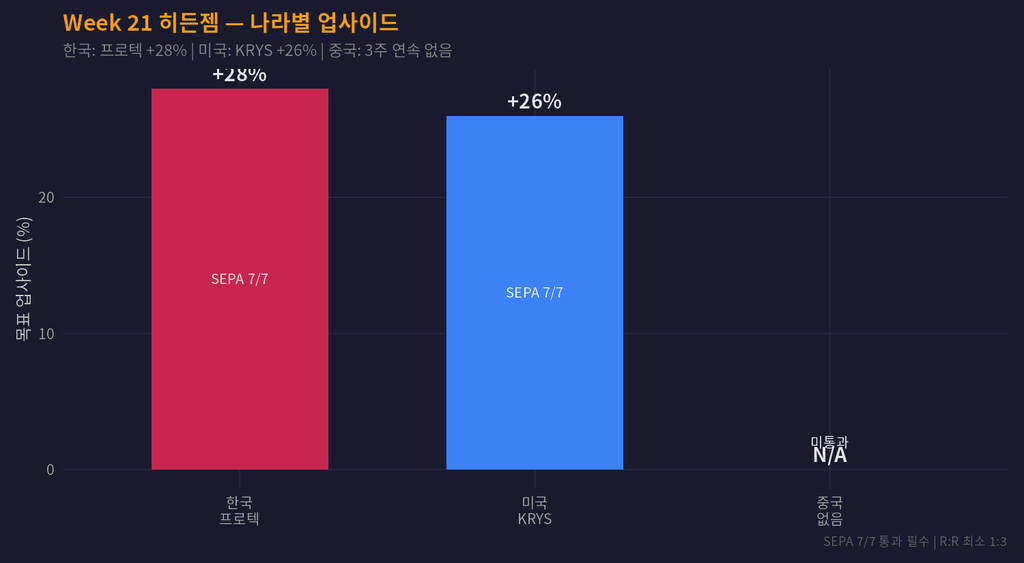

# 4 워치리스트 SEPA 재점검

## 4.1 활성 워치리스트

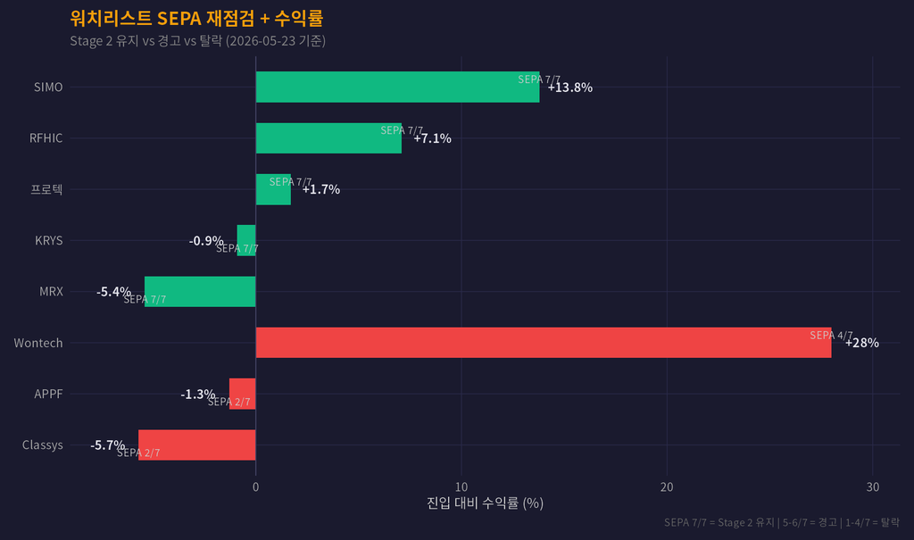

**SEPA 재점검 결과:**

- ✅ **Stage 2 유지 (7/7)**: 프로텍, RFHIC, SIMO, KRYS, MRX
- ⚠️ **경고 (4/7)**: Wontech — SMA150/200 정렬 미달, 수익률은 +28%
- ❌ **탈락 (2/7 이하)**: APPF (52주 고점 대비 -49%), Classys (SMA50 < SMA150)

# 5 리스크 매트릭스

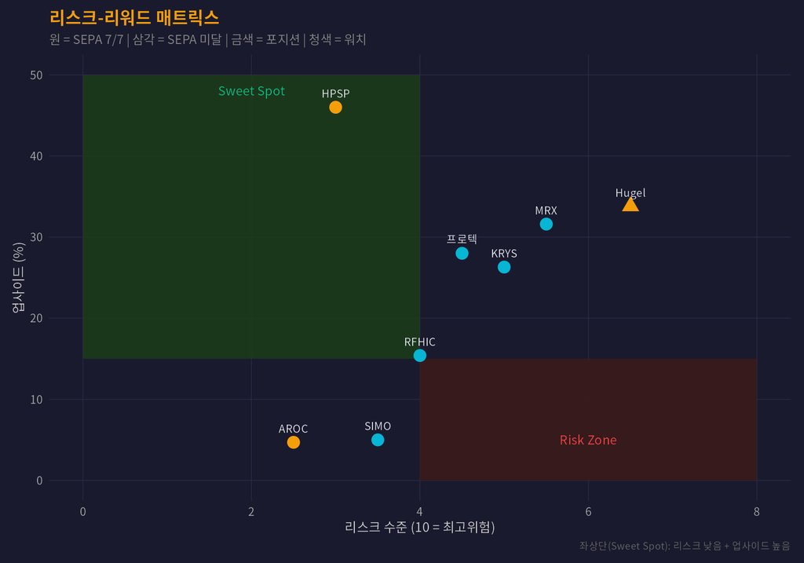

# 6 버핏 vs 린치 종합 렌즈

## 6.1 이번 주 히든젬 비교

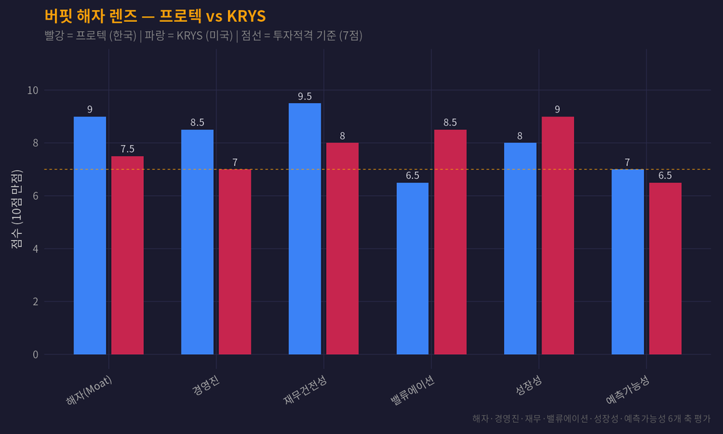

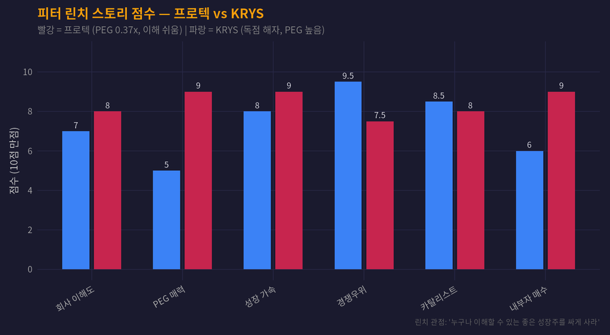

# 7 종합 판정

## 7.1 Week 21 최종 선정

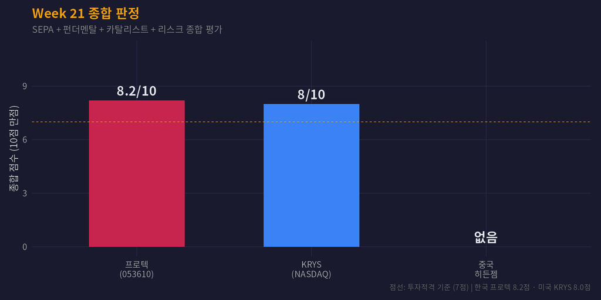

**🇰🇷 한국 히든젬: 프로텍 (053610) — 종합 8.2/10**

- SEPA 7/7 Stage 2 완벽 통과
- PEG 0.37x 극저평가 (성장 대비)
- 레이저 본딩 글로벌 최초 양산 — 기술 해자
- 자사주 18.2% 전량 소각 — 경영진 신뢰
- 리스크: 애널리스트 1명, ASE 고객 집중

**🇺🇸 미국 히든젬: Krystal Biotech (KRYS) — 종합 8.0/10**

- SEPA 7/7 Stage 2 완벽 통과
- FDA 독점 유전자 치료제 — 궁극의 해자
- OPM 46%, Gross Margin 95%, 현금 $1B 무부채
- 2개 파이프라인 2026 데이터 — 성장 스토리
- 리스크: PSR 21x 고평가, 단일 제품 의존

**🇨🇳 중국: 이번 주 조건 충족 종목 없음 (3주 연속)**

- 미중 무역갈등 + ADR 규제 리스크 → 신규 진입 부적절
- ZTO 6/7 근접이나 50SMA < 150SMA 미통과
- 조건 완화 없이 정직하게 보고

# 8 다음 주 모니터링 포인트

1. **Hugel SEPA 경고**: SMA150 < SMA200 지속 시 Stage 2 이탈 확정 → 매도 검토
2. **프로텍 52주 신고가 도전**: 현재 93,700원 vs 52주 고점 96,400원
3. **KRYS 파이프라인**: KB803 IOLITE Phase 3 top-line 데이터 Q4 2026
4. **RFHIC 방산 수주**: 한화 대형 수주 확인 시 포지션 편입 검토
5. **중국 시장**: ZTO 50SMA > 150SMA 돌파 시 재스크리닝

**면책 문구**

이 프로젝트는 가상 투자 시뮬레이션 목적으로 작성되었습니다. 실제 투자 권유가 아닙니다.